# F9_02_SIGNING_OFF_PHONE

Signing officer phone · Identifier report

## Overview

**Description**

Signing Officer Phone Number

**Table**

`F9-P02-T00-SIGNATURE` (one)

**Location code**

`F990-PC-PART-02`

**Family**

`F990-PC-PART-02` · siblings: F9_02_DISC_PREP_THIRD_PARTY_X, F9_02_PREP_FIRM_ADDR_CITY, F9_02_PREP_FIRM_ADDR_CNTR, F9_02_PREP_FIRM_ADDR_L1, F9_02_PREP_FIRM_ADDR_L2, F9_02_PREP_FIRM_ADDR_STATE

**Data type**

numeric (xsd: PhoneNumberType)

**Scope**

SG

**Status**

unreviewed

3

xpaths mapped (3 observed)

4,595,563

filings with a value

2009–2024

tax years observed

0

open flags (0 errors)

## Flags

No open flags.

## Xpaths

All mapped xpaths (under /Return/ReturnData or /Return/ReturnHeader), oldest first. Charts label each series by its xpath.

| Xpath | Form | First year | Last year | Versions | Filings | Repeats in |
| --- | --- | --- | --- | --- | --- | --- |
| Officer/Phone | Header | 2009 | 2012 | 18 | 541,583 | 0.0% |
| BusinessOfficerGrp/PhoneNum | Header | 2013 | 2024 | 37 | 4,052,980 | 0.0% |
| BusinessOfficerGrp/ForeignPhoneNum | Header | 2020 | 2024 | 16 | 1,000 | 0.0% |

## Coverage

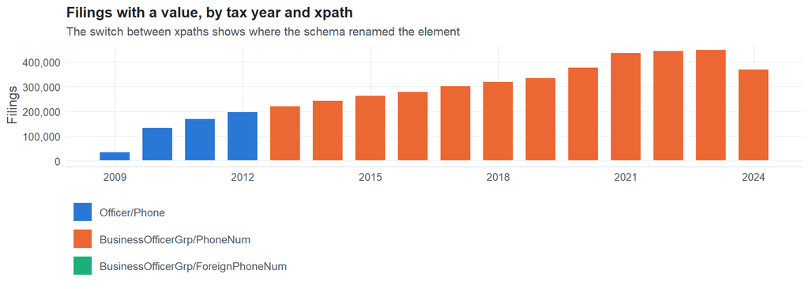

**Table view**

Table view: filings by tax year and series

| Tax year | Officer/Phone | BusinessOfficerGrp/PhoneNum | BusinessOfficerGrp/ForeignPhoneNum |
| --- | --- | --- | --- |
| 2009 | 36,733 | 0 | 0 |
| 2010 | 135,117 | 0 | 0 |
| 2011 | 170,254 | 0 | 0 |
| 2012 | 199,479 | 0 | 0 |
| 2013 | 0 | 221,735 | 0 |
| 2014 | 0 | 244,587 | 0 |
| 2015 | 0 | 265,114 | 0 |
| 2016 | 0 | 280,253 | 0 |
| 2017 | 0 | 303,966 | 0 |
| 2018 | 0 | 321,003 | 0 |
| 2019 | 0 | 335,848 | 0 |
| 2020 | 0 | 377,788 | 188 |
| 2021 | 0 | 437,083 | 203 |
| 2022 | 0 | 445,332 | 219 |
| 2023 | 0 | 450,080 | 217 |
| 2024 | 0 | 370,191 | 173 |

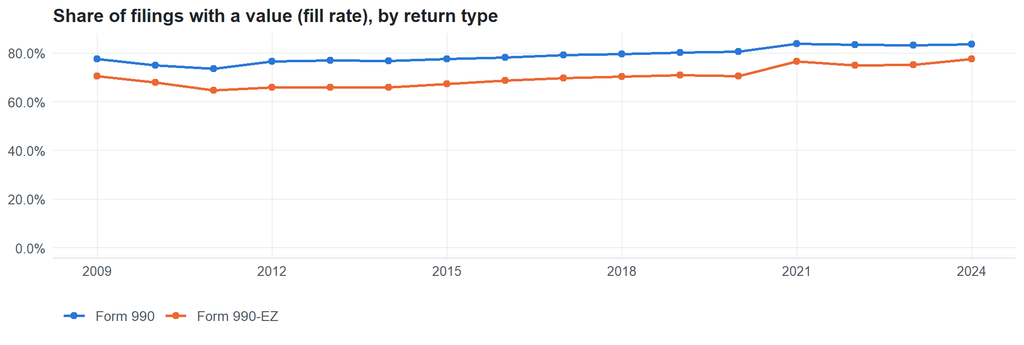

**Table view**

Table view: fill rate

| Tax year | Return type | Filings | All filings | Fill rate |
| --- | --- | --- | --- | --- |
| 2009 | Form 990 | 25,830 | 33,311 | 77.54% |
| 2009 | Form 990-EZ | 10,903 | 15,470 | 70.48% |
| 2010 | Form 990 | 92,081 | 123,025 | 74.85% |
| 2010 | Form 990-EZ | 43,036 | 63,326 | 67.96% |
| 2011 | Form 990 | 117,132 | 159,504 | 73.44% |
| 2011 | Form 990-EZ | 53,122 | 82,048 | 64.75% |
| 2012 | Form 990 | 137,651 | 179,688 | 76.61% |
| 2012 | Form 990-EZ | 61,828 | 93,750 | 65.95% |
| 2013 | Form 990 | 152,934 | 198,855 | 76.91% |
| 2013 | Form 990-EZ | 68,801 | 104,375 | 65.92% |
| 2014 | Form 990 | 167,942 | 218,619 | 76.82% |
| 2014 | Form 990-EZ | 76,645 | 116,417 | 65.84% |
| 2015 | Form 990 | 181,038 | 233,519 | 77.53% |
| 2015 | Form 990-EZ | 84,076 | 124,894 | 67.32% |
| 2016 | Form 990 | 190,695 | 243,903 | 78.18% |
| 2016 | Form 990-EZ | 89,558 | 130,484 | 68.64% |
| 2017 | Form 990 | 207,017 | 261,612 | 79.13% |
| 2017 | Form 990-EZ | 96,948 | 139,144 | 69.67% |
| 2018 | Form 990 | 215,833 | 271,442 | 79.51% |
| 2018 | Form 990-EZ | 105,170 | 149,384 | 70.40% |
| 2019 | Form 990 | 227,712 | 283,694 | 80.27% |
| 2019 | Form 990-EZ | 108,135 | 152,622 | 70.85% |
| 2020 | Form 990 | 258,236 | 320,342 | 80.61% |
| 2020 | Form 990-EZ | 119,738 | 169,864 | 70.49% |
| 2021 | Form 990 | 282,115 | 336,480 | 83.84% |
| 2021 | Form 990-EZ | 155,158 | 202,724 | 76.54% |
| 2022 | Form 990 | 291,133 | 349,055 | 83.41% |
| 2022 | Form 990-EZ | 154,406 | 206,130 | 74.91% |
| 2023 | Form 990 | 295,164 | 354,768 | 83.20% |
| 2023 | Form 990-EZ | 155,124 | 206,379 | 75.16% |
| 2024 | Form 990 | 231,631 | 277,298 | 83.53% |
| 2024 | Form 990-EZ | 138,728 | 178,867 | 77.56% |

## Values

| Result | Check | Detail |
| --- | --- | --- |
| ✓ pass | Values have the Phone format | 100.0% of values match ^9999999999$ |
| ⚠ fail | Stored as text | data type is numeric: leading zeros and letters would be lost |
| ▲ warn | No placeholder values | 6,956 filings use a placeholder such as 000000000 |
| ⓘ info | Leading zeros present | at least 1% of values start with 0 in some year, so numeric storage would change them |

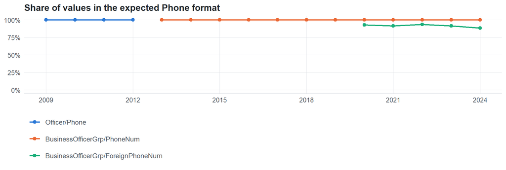

Value shapes (9 = digit, A = letter)

| Series | Shape | Expected | Filings |
| --- | --- | --- | --- |
| Officer/Phone | 9999999999 | yes | 541,583 |
| BusinessOfficerGrp/PhoneNum | 9999999999 | yes | 4,052,980 |
| BusinessOfficerGrp/ForeignPhoneNum | 9999999999 | yes | 916 |
| BusinessOfficerGrp/ForeignPhoneNum | 99999999999 | no | 42 |
| BusinessOfficerGrp/ForeignPhoneNum | 999999999999 | no | 29 |
| BusinessOfficerGrp/ForeignPhoneNum | 9999999999999 | no | 5 |
| BusinessOfficerGrp/ForeignPhoneNum | 99999999999999 | no | 3 |
| BusinessOfficerGrp/ForeignPhoneNum | 999999999 | no | 2 |
| BusinessOfficerGrp/ForeignPhoneNum | 999999999999999999999 | no | 1 |

## Examples

| Tax year | Return | Xpath | Organization | Value | Source |
| --- | --- | --- | --- | --- | --- |
| 2024 | 990 | BusinessOfficerGrp/ForeignPhoneNum | THE AMERICAN CHAMBER OF COMMERCE | 1085190800 | [XML](https://gt990datalake-rawdata.s3.amazonaws.com/EfileData/XmlFiles/202533189349303503_public.xml) |
| 2024 | 990 | BusinessOfficerGrp/PhoneNum | OWL CREEK COUNTRY CLUB | 5022454157 | [XML](https://gt990datalake-rawdata.s3.amazonaws.com/EfileData/XmlFiles/202513219349315726_public.xml) |
| 2023 | 990 | BusinessOfficerGrp/ForeignPhoneNum | HONG KONG INTERNATIONAL SCHOOL ASSOCIATION LIMITED | 85231497333 | [XML](https://gt990datalake-rawdata.s3.amazonaws.com/EfileData/XmlFiles/202501539349300310_public.xml) |
| 2023 | 990EZ | BusinessOfficerGrp/PhoneNum | SAN ANTONIO HOMESCHOOL ATHLETIC ASSOICATION | 2107383542 | [XML](https://gt990datalake-rawdata.s3.amazonaws.com/EfileData/XmlFiles/202432609349201843_public.xml) |
| 2022 | 990 | BusinessOfficerGrp/ForeignPhoneNum | PARTNERSHIP FOR ECONOMIC POLICY INC | 4208632681 | [XML](https://gt990datalake-rawdata.s3.amazonaws.com/EfileData/XmlFiles/202342869349301904_public.xml) |
| 2022 | 990 | BusinessOfficerGrp/PhoneNum | FRANK TOWN OPEN HEARTS MINISTRY INC | 6158070782 | [XML](https://gt990datalake-rawdata.s3.amazonaws.com/EfileData/XmlFiles/202303189349302170_public.xml) |
| 2021 | 990 | BusinessOfficerGrp/ForeignPhoneNum | BERMUDA INSTITUTE OF OCEAN SCIENCES | 4412971880 | [XML](https://gt990datalake-rawdata.s3.amazonaws.com/EfileData/XmlFiles/202203199349327145_public.xml) |
| 2021 | 990EZ | BusinessOfficerGrp/PhoneNum | BLAINE 1 INC | 4063572244 | [XML](https://gt990datalake-rawdata.s3.amazonaws.com/EfileData/XmlFiles/202201369349200340_public.xml) |
| 2020 | 990 | BusinessOfficerGrp/ForeignPhoneNum | SAINT MARY’S UNIVERSITY | 9024918658 | [XML](https://gt990datalake-rawdata.s3.amazonaws.com/EfileData/XmlFiles/202200429349301005_public.xml) |
| 2020 | 990EZ | BusinessOfficerGrp/PhoneNum | GENESEE TOWNSHIP VETERANS MEMORIAL | 8106402600 | [XML](https://gt990datalake-rawdata.s3.amazonaws.com/EfileData/XmlFiles/202142879349200014_public.xml) |
| 2019 | 990 | BusinessOfficerGrp/PhoneNum | FOSTERING HOPE | 2168166888 | [XML](https://gt990datalake-rawdata.s3.amazonaws.com/EfileData/XmlFiles/202033519349300713_public.xml) |
| 2018 | 990EZ | BusinessOfficerGrp/PhoneNum | Woodlawn Cemetery Association Inc | 9046522230 | [XML](https://gt990datalake-rawdata.s3.amazonaws.com/EfileData/XmlFiles/201933179349200908_public.xml) |

## Reviewer checklist

- The definition matches the form line and instructions for every xpath’s schema years.
- Every xpath pooled here measures the same thing on the 990 and 990-EZ (close enough for analysis).
- The coverage chart has no unexplained gaps or jumps between tax years.
- Each open flag is fixed, or accepted with a note in validation_log.csv.
- The data type is text so leading zeros and letters survive.
- The identifier belongs to the entity the variable names (the filer, preparer, related organization…).
- Formats with and without punctuation (e.g. ZIP+4, dashes) are normalized consistently downstream.

Record the review as a row in `inst/extdata/src/validation_log.csv` (variable_name, reviewer, date, status, note). Evidence built 2026-09-23 17:09:04 MST from the ef2 DuckDB builds (tax years 2009–2024).